# upa_analysis - draft

Peter Higgins

5/31/2022

## Data in 2 files

- all_hospitalized_uc.csv plus colectomy data - to be merged
- upa_ifx_tofa_hospitalized_uc.csv Let’s explore

all_hospitalized - includes 10481 CRPs, 405 FCPs - all are controls - no upa, tofa, ifx - from 2012-02-11 to 2021-09-23 - 679 unique individuals, 198 went to colectomy

```r
all_hosp <- read_csv('all_hospitalized_uc.csv')
all_hosp |> distinct(cpi_num, .keep_all = TRUE) |> count()
```

```
## # A tibble: 1 × 1
##       n
##   <int>
## 1   679
```

```r
# total 679 on CS, possibly some got IFX, some Cyclo, possibly a few tofa. Ended before Upa

all_hosp_colect <- readxl::read_excel('all_hospitalized_colectomy.xlsx') |> distinct(PatientID, .keep_all = TRUE)

all_hosp <- left_join(all_hosp, all_hosp_colect)
# how many colect

all_hosp_colect |> count()
```

```
## # A tibble: 1 × 1
##       n
##   <int>
## 1   198
```

```r
# 198 colect/ total 679 on CS+
all_hosp |>
  filter(test == "FCP") |>
  select(cpi_num ,admit_date,
         test_date, value) |>
  mutate(day = as.numeric(test_date - admit_date + 1)) |>
  group_by(day) |>
  summarize(mean_fcp = mean(value),
            count = n()) |>
  gt()
```

| day | mean_fcp | count |
| --- | --- | --- |
| 1 | 880.2267 | 15 |
| 2 | 1366.8813 | 155 |
| 3 | 1304.1568 | 88 |
| 4 | 784.0651 | 43 |
| 5 | 1495.5333 | 33 |
| 6 | 1293.6100 | 10 |
| 7 | 1236.5588 | 17 |
| 8 | 1918.7286 | 14 |
| 9 | 477.8167 | 6 |
| 10 | 388.6000 | 9 |
| 11 | 188.6143 | 7 |
| 12 | 2084.5000 | 4 |
| 13 | 1189.9500 | 4 |

```r
all_hosp |>
  filter(test == "CRP") |>
  select(cpi_num ,admit_date,
         test_date, value) |>
  mutate(day = as.numeric(test_date - admit_date + 1)) |>
  group_by(day) |>
  summarize(mean_crp = mean(value*10),
            count = n()) |>
  print(n = 86) |>
  gt()
```

```
## # A tibble: 86 × 3
##      day mean_crp count
##    <dbl>    <dbl> <int>
##  1     1    58.9   1637
##  2     2    66.7   1173
##  3     3    55.3   1233
##  4     4    39.2   1270
##  5     5    30.1   1117
##  6     6    30.5    862
##  7     7    36.5    675
##  8     8    33.0    492
##  9     9    35.7    403
## 10    10    35.3    326
## 11    11    31.8    258
## 12    12    26.0    192
```

[output cut: 74 more lines]

| day | mean_crp | count |
| --- | --- | --- |
| 1 | 58.877214 | 1637 |
| 2 | 66.699062 | 1173 |
| 3 | 55.317924 | 1233 |
| 4 | 39.249606 | 1270 |
| 5 | 30.087735 | 1117 |
| 6 | 30.508121 | 862 |
| 7 | 36.477037 | 675 |
| 8 | 33.036585 | 492 |
| 9 | 35.699752 | 403 |
| 10 | 35.309816 | 326 |
| 11 | 31.813953 | 258 |
| 12 | 25.973958 | 192 |
| 13 | 30.767123 | 146 |
| 14 | 40.305556 | 108 |
| 15 | 19.785047 | 107 |
| 16 | 46.869565 | 69 |
| 17 | 38.508772 | 57 |
| 18 | 23.658537 | 41 |
| 19 | 19.170732 | 41 |
| 20 | 19.095238 | 42 |
| 21 | 10.600000 | 40 |
| 22 | 8.500000 | 24 |
| 23 | 3.705882 | 34 |
| 24 | 2.846154 | 26 |
| 25 | 75.941176 | 17 |
| 26 | 87.714286 | 14 |
| 27 | 88.071429 | 14 |
| 28 | 13.000000 | 1 |
| 29 | 17.000000 | 1 |
| 30 | 21.000000 | 1 |

[output cut: 56 more lines]

Now let’s look at advanced therapies - 1890 lab values (Crp and FCP) for ifx, 368 for tofa, 243 for upa - from 2014-01-06 to 2023-01-06 - 2455 CRPs, 46 FCPs (note only recently routinely getting FCP, mostly in Upa) - in 207 unique individuals - among unique individuals IFX - 61 colect, 95 not tofa - 14 colect, 17 not upa - 5 colect, 15 not

IFX no colect - d3 74.7, d7 33.5, d14 27.3 IFX eventual colect - d3 71, d7 59.7, d14 40.2 tofa no colect - d3 61.3, d7 32.7, d14 24.2 tofa eventual colect - d3 38.9, d7 20.5, d14 154 upa no colect - d3 41.2, d7 11.3, d14 79.2 upa eventual colect - d3 64.6, d7 51.4, d14 84

Full CRP table below

Then group by Rx and colectomy (0/1) and average daily value of CRP (0-IFX means people who got IFX and no colectomy)

```r
adv_rx <- read_csv('upa_ifx_tofa_hospitalized_uc.csv')
adv_rx |>
  filter(test == "FCP") |>
  select(cpi_num,admit_date, cohort,
         test_date, value) |>
  mutate(day = as.numeric(test_date - admit_date + 1)) |>
  group_by(cohort, day) |>
  summarize(mean_fcp = mean(value),
            count = n()) |>
  gt()
```

| day | mean_fcp | count |
| --- | --- | --- |
| upa |  |  |
| 1 | 1912.7143 | 7 |
| 2 | 2247.1600 | 5 |
| 4 | 2090.3000 | 3 |
| 5 | 2342.6000 | 2 |
| 6 | 4452.0000 | 1 |
| 7 | 1852.2500 | 4 |
| 20 | 61.7000 | 2 |
| 23 | 32.0000 | 1 |
| 24 | 522.0000 | 2 |
| 32 | 34.0000 | 1 |
| 34 | 125.0000 | 1 |
| 38 | 46.0000 | 1 |
| 39 | 481.0000 | 1 |
| 43 | 2425.0000 | 1 |
| 47 | 290.0000 | 1 |
| 48 | 34.8000 | 1 |
| 51 | 78.0000 | 1 |
| 58 | 444.1000 | 3 |
| 65 | 1124.5000 | 1 |
| 68 | 1846.6000 | 1 |
| 93 | 109.8333 | 3 |
| 114 | 59.5500 | 2 |
| 124 | 47.7000 | 1 |

```r
adv_rx |>
  filter(test == "CRP") |>
  select(cpi_num,admit_date, cohort, colect,
         test_date, value) |>
  mutate(day = as.numeric(test_date - admit_date + 1)) |>
  group_by(colect, cohort, day) |>
  summarize(mean_crp = mean(value*10),
            count = n()) |>
  filter(day < 15) |>
  gt()
```

| day | mean_crp | count |
| --- | --- | --- |
| 0 - ifx |  |  |
| 1 | 83.306452 | 124 |
| 2 | 100.620690 | 116 |
| 3 | 74.710744 | 121 |
| 4 | 49.609756 | 123 |
| 5 | 37.185185 | 108 |
| 6 | 33.797753 | 89 |
| 7 | 33.455696 | 79 |
| 8 | 35.118644 | 59 |
| 9 | 32.654545 | 55 |
| 10 | 23.860465 | 43 |
| 11 | 25.968750 | 32 |
| 12 | 25.629630 | 27 |
| 13 | 25.521739 | 23 |
| 14 | 27.300000 | 20 |
| 0 - tofa |  |  |
| 1 | 70.894737 | 19 |
| 2 | 80.187500 | 16 |
| 3 | 61.312500 | 16 |
| 4 | 45.117647 | 17 |
| 5 | 38.066667 | 15 |
| 6 | 31.642857 | 14 |
| 7 | 32.666667 | 12 |
| 8 | 23.333333 | 12 |
| 9 | 25.600000 | 10 |
| 10 | 27.857143 | 7 |
| 11 | 26.000000 | 7 |
| 12 | 18.833333 | 6 |
| 13 | 19.666667 | 6 |
| 14 | 24.200000 | 5 |

[output cut: 60 more lines]

```r
adv_rx |>
  distinct(cpi_num, ,.keep_all = TRUE) |>
  tabyl(cohort, colect)
```

```
##  cohort  0  1
##     ifx 95 61
##    tofa 17 14
##     upa 15  5
```

## When does colectomy occur?

Let’s see when colectomies occur. Are some treatments just delaying colectomy?

### Clean up and bind rows between controls and advRx first

```r
adv_rx2 <- adv_rx |>
  select(cpi_num, cohort, admit_date, colect_date, colect) |>
  rename(colectomy = colect) |>
  replace_na(list(colectomy = 0)) |>
  distinct(cpi_num, .keep_all = TRUE) |>
  mutate(cpi_num = as.numeric(cpi_num))
all_hosp2 <- all_hosp |>
  select(cpi_num, cohort, admit_date, Date, colectomy) |>
  rename(colect_date = Date) |>
  mutate(colect_date = as.Date( as.character(colect_date))) |>
   distinct(cpi_num, .keep_all = TRUE) |>
  replace_na(list(colectomy = 0))

all_colect <- bind_rows(adv_rx2, all_hosp2)
```

### Now set up plot

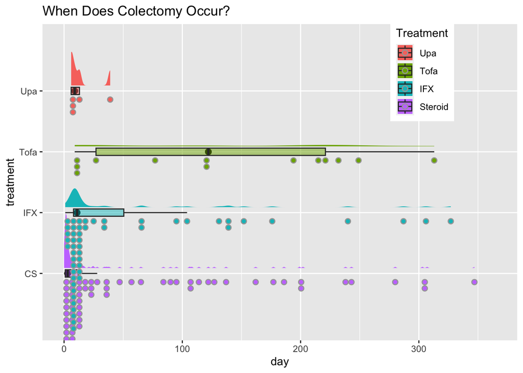

```r
all_colect |>
  filter(colectomy == 1) |>
  select(cohort, admit_date, colect_date) |>
  mutate(day = as.numeric(colect_date - admit_date)) |>
  ggplot(aes(x = cohort, y = day, fill = fct_rev(cohort))) +
   stat_halfeye(adjust = 0.5, justification = -0.1, .width = 0) +
  geom_boxplot(
    width = 0.12,
    # removing outliers
    outlier.color = NA,
    alpha = 0.5
  ) +
  stat_dots(side = "left",
            justification = 1.1,
            binwidth = 5 ) +
  scale_y_continuous(limits = c(0,365)) +
  coord_flip() +
  theme(legend.position = c(0.8,0.85)) +
  labs(x = 'treatment', title = "When Does Colectomy Occur?", fill = "Treatment") +
  scale_x_discrete(labels = c("upa" = "Upa", "tofa" = "Tofa", "ifx" = "IFX", "ctls" = "CS")) +
  scale_fill_discrete(labels = c("Upa", "Tofa", "IFX", "Steroid"))
```

Looks like if we can catch people early enough with Upa, no colectomies after d39. Much bigger spread with other Advanced Rx

### Length of Followup for Upa?

Is it too short to be comparable? Looks OK

```r
adv_rx |>
  filter(cohort == "upa") |>
  distinct(cpi_num, .keep_all = TRUE) |>
  select(cohort, admit_date, colect_date) |>
  mutate(cday = as.numeric(colect_date - admit_date)) |>
  mutate(fu = as.numeric(today() - admit_date)) |>
  arrange(-fu)
```

```
## # A tibble: 20 × 5
##    cohort admit_date colect_date  cday    fu
##    <chr>  <date>     <date>      <dbl> <dbl>
##  1 upa    2022-04-02 2022-04-08      6   412
##  2 upa    2022-05-12 NA             NA   372
##  3 upa    2022-05-26 NA             NA   358
##  4 upa    2022-05-27 NA             NA   357
##  5 upa    2022-05-27 2022-06-02      6   357
##  6 upa    2022-06-20 NA             NA   333
##  7 upa    2022-06-23 NA             NA   330
##  8 upa    2022-06-23 NA             NA   330
##  9 upa    2022-07-01 NA             NA   322
## 10 upa    2022-07-02 NA             NA   321
## 11 upa    2022-07-25 NA             NA   298
## 12 upa    2022-07-31 NA             NA   292
## 13 upa    2022-08-02 2022-08-11      9   290
## 14 upa    2022-08-10 NA             NA   282
## 15 upa    2022-09-11 NA             NA   250
## 16 upa    2022-09-13 NA             NA   248
## 17 upa    2022-09-17 2022-09-30     13   244
## 18 upa    2022-09-19 2022-10-28     39   242
## 19 upa    2022-11-18 NA             NA   182
## 20 upa    2023-01-06 NA             NA   133
```

range 130-409 days median 307 days One on 45 mg qd One on 30 upa + stelara All of the rest on 30 mg Upa

## How many colectomy by day 7 or 14?

```r
adv_rx |>
  filter(colect == 1) |>
  distinct(cpi_num, .keep_all = TRUE) |>
  select(cohort, admit_date, colect_date) |>
  mutate(day = as.numeric(colect_date - admit_date + 1)) |>
  arrange(cohort, day) |>
  print(n = Inf)
```

```
## # A tibble: 80 × 4
##    cohort admit_date colect_date   day
##    <chr>  <date>     <date>      <dbl>
##  1 ifx    2018-12-30 2018-12-31      2
##  2 ifx    2016-11-22 2016-11-24      3
##  3 ifx    2017-07-15 2017-07-19      5
##  4 ifx    2020-06-17 2020-06-22      6
##  5 ifx    2017-01-16 2017-01-21      6
##  6 ifx    2017-11-02 2017-11-08      7
##  7 ifx    2018-10-29 2018-11-04      7
##  8 ifx    2020-07-31 2020-08-06      7
##  9 ifx    2016-11-07 2016-11-14      8
## 10 ifx    2018-06-29 2018-07-07      9
## 11 ifx    2015-02-10 2015-02-18      9
## 12 ifx    2014-12-08 2014-12-16      9
```

[output cut: 68 more lines]

```r
all_hosp2|>
  filter(colectomy == 1) |>
  distinct(cpi_num, .keep_all = TRUE) |>
  select(cohort, admit_date, colect_date) |>
  mutate(day = as.numeric(colect_date - admit_date + 1)) |>
  arrange(cohort, day) |>
  print(n = Inf)
```

```
## # A tibble: 198 × 4
##     cohort admit_date colect_date   day
##     <chr>  <date>     <date>      <dbl>
##   1 ctls   2021-09-01 2014-01-21  -2779
##   2 ctls   2018-09-17 2013-06-04  -1930
##   3 ctls   2021-09-15 2016-11-27  -1752
##   4 ctls   2021-08-11 2017-01-13  -1670
##   5 ctls   2020-05-08 2017-03-22  -1142
##   6 ctls   2016-10-28 2014-09-29   -759
##   7 ctls   2021-07-28 2020-01-13   -561
##   8 ctls   2018-01-12 2016-10-07   -461
##   9 ctls   2018-06-04 2017-05-26   -373
##  10 ctls   2018-12-13 2018-03-13   -274
##  11 ctls   2020-01-08 2019-04-22   -260
##  12 ctls   2018-11-30 2018-03-30   -244
```

[output cut: 186 more lines]

Will need to pull more recent data to get - CRP on CS patients - FCP on CS patients - more complete and accurate overall #s (note weirdness with CS and colectomy dates [some negative #s of days])